# 数据挖掘 homework3

## 王越 21210980077

```python
import numpy as np
import pandas as pd
import matplotlib.pyplot as plt
import statsmodels.api as sm
from functools import cmp_to_key
%matplotlib inline
```

# 1. 读入数据，查看数据情况

```python
df = pd.read_csv('data.csv')
df
```

|  | delivery_mode | float_delivery_fee | float_minimum_order_amount | is_new | is_premium | order_lead_time | recent_order_num | compare_rating | food_score | service_score | ... | log_average_cost | log_float_minimum_order_amount | log_float_delivery_fee | open_time | open08 | open12 | open18 | open23 | shop_type | district0 |
| --- | --- | --- | --- | --- | --- | --- | --- | --- | --- | --- | --- | --- | --- | --- | --- | --- | --- | --- | --- | --- | --- |
| 0 | 商家配送 | 7 | 0 | False | False | 45 | 2123 | 0.494869 | 4.50012 | 4.47928 | ... | 3.549131 | 0.000000 | 2.079442 | 14.250000 | 0 | 1 | 1 | 1 | 快餐简餐 | 海淀区 |
| 1 | 蜂鸟专送 | 5 | 20 | False | True | 35 | 4546 | 0.700551 | 4.61939 | 4.74763 | ... | 3.884076 | 3.044522 | 1.791759 | 11.000000 | 0 | 1 | 1 | 0 | 特色菜系 | 海淀区 |
| 2 | 商家配送 | 6 | 20 | False | True | 51 | 1194 | 0.466459 | 4.61707 | 4.47224 | ... | 4.013129 | 3.044522 | 1.945910 | 11.000000 | 0 | 1 | 1 | 0 | 快餐简餐 | 海淀区 |
| 3 | 商家配送 | 10 | 20 | False | False | 44 | 375 | 0.375857 | 4.81023 | 4.70941 | ... | 3.100909 | 3.044522 | 2.397895 | 11.500000 | 0 | 1 | 1 | 0 | 特色菜系 | 海淀区 |
| 4 | 商家配送 | 7 | 30 | False | False | 38 | 6664 | 0.533149 | 4.60685 | 4.56124 | ... | 3.594881 | 3.433987 | 2.079442 | 12.250000 | 0 | 1 | 1 | 0 | 特色菜系 | 海淀区 |
| ... | ... | ... | ... | ... | ... | ... | ... | ... | ... | ... | ... | ... | ... | ... | ... | ... | ... | ... | ... | ... | ... |
| 32038 | 商家配送 | 5 | 20 | True | False | 0 | 0 | -1.000000 | -1.00000 | -1.00000 | ... | 0.000000 | 3.044522 | 1.791759 | 10.500000 | 0 | 1 | 1 | 0 | 快餐简餐 | 东城区 |
| 32039 | 商家配送 | 5 | 15 | True | False | 0 | 0 | -1.000000 | -1.00000 | -1.00000 | ... | 0.000000 | 2.772589 | 1.791759 | 12.000000 | 0 | 1 | 1 | 0 | 小吃夜宵 | 海淀区 |
| 32040 | 蜂鸟专送 | 5 | 20 | True | False | 35 | 0 | -1.000000 | -1.00000 | -1.00000 | ... | 0.000000 | 3.044522 | 1.791759 | 10.000000 | 0 | 1 | 1 | 0 | 快餐简餐 | 丰台区 |
| 32041 | 商家配送 | 5 | 20 | True | False | 0 | 0 | -1.000000 | -1.00000 | -1.00000 | ... | 0.000000 | 3.044522 | 1.791759 | 10.666667 | 0 | 1 | 1 | 0 | 小吃夜宵 | 丰台区 |
| 32042 | 商家配送 | 10 | 20 | True | False | 0 | 2 | 0.000000 | 5.00000 | 5.00000 | ... | 4.514151 | 3.044522 | 2.397895 | 10.500000 | 0 | 1 | 1 | 0 | 果蔬生鲜 | 丰台区 |

32043 rows × 29 columns

```python
df.describe()
```

|  | float_delivery_fee | float_minimum_order_amount | order_lead_time | recent_order_num | compare_rating | food_score | service_score | star_level | manjian_discount | new_user | ... | average_cost | log_recent_order_num | log_average_cost | log_float_minimum_order_amount | log_float_delivery_fee | open_time | open08 | open12 | open18 | open23 |
| --- | --- | --- | --- | --- | --- | --- | --- | --- | --- | --- | --- | --- | --- | --- | --- | --- | --- | --- | --- | --- | --- |
| count | 32043.000000 | 32043.000000 | 32043.000000 | 32043.000000 | 32043.000000 | 32043.000000 | 32043.000000 | 32043.000000 | 32043.000000 | 32043.000000 | ... | 32043.000000 | 32043.000000 | 32043.000000 | 32043.000000 | 32043.000000 | 32043.000000 | 32043.000000 | 32043.000000 | 32043.000000 | 32043.000000 |
| mean | 8.354555 | 22.872265 | 30.315888 | 465.677277 | 0.447225 | 4.188155 | 4.272178 | 4.237300 | 0.197525 | 19.156103 | ... | 77.055869 | 4.758456 | 3.542648 | 2.957637 | 2.101372 | 11.901988 | 0.055644 | 0.962113 | 0.984583 | 0.153575 |
| std | 7.193095 | 20.708794 | 12.336985 | 899.144078 | 0.436516 | 1.343901 | 1.359899 | 1.339088 | 0.171380 | 4.249121 | ... | 3667.180341 | 1.949278 | 1.104204 | 0.782219 | 0.474929 | 2.813076 | 0.229236 | 0.190925 | 0.123205 | 0.360546 |
| min | 0.000000 | 0.000000 | 0.000000 | 0.000000 | -1.000000 | -1.000000 | -1.000000 | -1.000000 | 0.000000 | 0.000000 | ... | 0.000000 | 0.000000 | 0.000000 | 0.000000 | 0.000000 | 0.000000 | 0.000000 | 0.000000 | 0.000000 | 0.000000 |
| 25% | 5.000000 | 20.000000 | 26.000000 | 45.000000 | 0.279187 | 4.340740 | 4.401000 | 4.400000 | 0.010000 | 17.000000 | ... | 27.483474 | 3.828641 | 3.349324 | 3.044522 | 1.791759 | 10.833333 | 0.000000 | 1.000000 | 1.000000 | 0.000000 |
| 50% | 7.000000 | 20.000000 | 31.000000 | 124.000000 | 0.514768 | 4.537510 | 4.642550 | 4.600000 | 0.166667 | 20.000000 | ... | 38.522888 | 4.828314 | 3.676880 | 3.044522 | 2.079442 | 11.750000 | 0.000000 | 1.000000 | 1.000000 | 0.000000 |
| 75% | 9.000000 | 20.000000 | 37.000000 | 452.000000 | 0.739631 | 4.732130 | 4.834000 | 4.800000 | 0.323077 | 21.000000 | ... | 57.557235 | 6.115892 | 4.070005 | 3.044522 | 2.302585 | 12.500000 | 0.000000 | 1.000000 | 1.000000 | 0.000000 |
| max | 200.000000 | 500.000000 | 80.000000 | 13571.000000 | 0.988889 | 5.000000 | 5.000000 | 5.000000 | 0.958333 | 45.000000 | ... | 655873.941558 | 9.515764 | 13.393725 | 6.216606 | 5.303305 | 24.000000 | 1.000000 | 1.000000 | 1.000000 | 1.000000 |

8 rows × 21 columns

### 共有32043个样本数据，每个样本数据有29个字段

# 2. 绘制对数月销量的直方图，观察其特征，并作出解释

```python
log_month = df['log_recent_order_num']
log_month.describe()
```

```
count    32043.000000
mean         4.758456
std          1.949278
min          0.000000
25%          3.828641
50%          4.828314
75%          6.115892
max          9.515764
Name: log_recent_order_num, dtype: float64
```

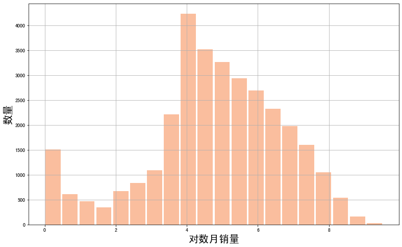

```python
### 第二题
### 直方图绘制
plt.figure(figsize = (13,8))
plt.hist(log_month,bins = 20,color = '#FABE9E',rwidth = 0.9)
plt.ylabel('数量',fontsize = 20)
plt.xlabel('对数月销量',fontsize = 20)
plt.grid()
```

### 共有32043份样本数据，统计对数月销量绘制的直方图如上图所示。对数月租金分布呈左偏分布，对数月租金平均数大于众数。对数月租金在4到6的情形最为常见。

# 3. 绘制行政区划与月销量对比箱线图，并作出解释（要求箱线图的箱子按中位数大小排列）

```python
### 第三题

uni_district = df['district'].unique() ### 取所有城区的唯一值
lst = [] ### 创建每个城区对数月销量数据的列表
for i in uni_district:
    obj = df[df['district'] == i]['log_recent_order_num']
    obj.name = i
    lst.append(obj)
lst.sort(key = cmp_to_key(lambda x,y:x.median() - y.median()),reverse = True) ### 根据中位数排序
labels = [v.name for v in lst] ### 获取排序后的标签
```

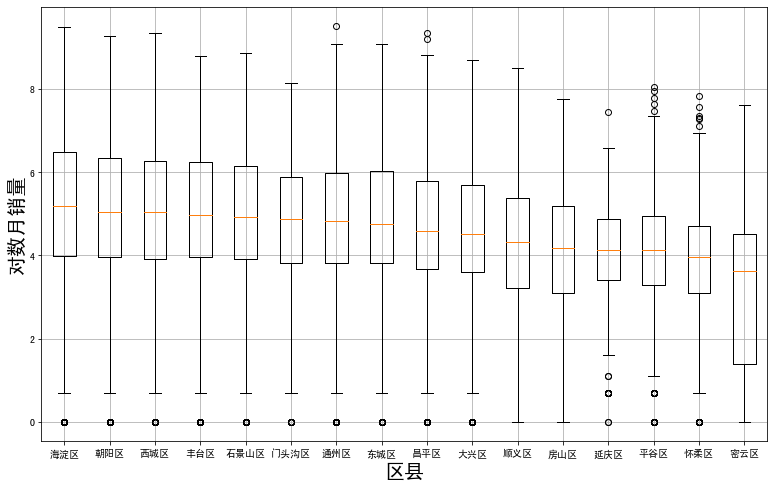

```python
### 绘制箱线图
plt.figure(figsize = (13,8))
plt.boxplot(lst,labels = labels)
plt.ylabel('对数月销量',fontsize = 20)
plt.xlabel('区县',fontsize = 20)
plt.grid()
```

### 可以看到海淀区、朝阳区、西城区等闹市区因为人员密集所以月销量总体比较高，而怀柔、密云等郊区因为人员稀疏所以月销量总体比较低。

# 4. 绘制四个用餐高峰期是否营业（open08、open12、open18、open23）与对数月销量对比箱线图（四个子图）。要求：在一张大图中放入四个子图（提示：使用基础绘图函数时可用par参数，使用ggplot2时使用facet_wrap分面或者ggpubr包中的ggarrange函数）

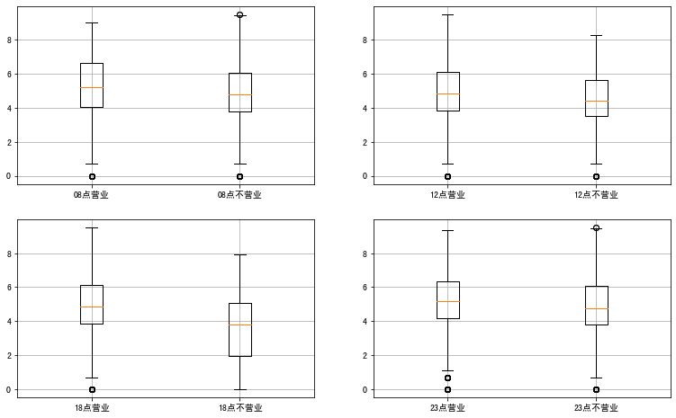

```python
### 第四题
time = ['open08','open12','open18','open23']
### 分子图绘制箱线图
plt.figure(figsize = (13,8))
for i in range(len(time)):
    plt.subplot(2,2,i+1)
    plt.boxplot([df[df[time[i]] == 1]['log_recent_order_num'],\
                 df[df[time[i]] == 0]['log_recent_order_num']],labels = [time[i][-2:]+'点营业',\
                                                                        time[i][-2:]+'点不营业'])
    plt.grid()
```

### 可以看到，在每个时间段营业的店家比起不营业的店家总体月销量都要高，这在18点体现的尤为明显，因为18点是饭点，用餐高峰。而8点、12点和23点影响较小。

# 5. 建立回归模型，使用BIC准则进行逐步回归得到最终模型，查看最终模型中的系数大小及其显著性，并解读系数。要求：

### 1） 因变量：对数月销量

### 2） 自变量：对数平均每单费用、配送模式、对数配送费、对数起送费、起送时间、所在行政区（北京市16区）、是否有外卖保、是否开发票、满减折扣率、其他优惠活动数、新用户减免、每天营业时长、8点是否营业、12点是否营业、16点是否营业、23点是否营业、商家分类、是否新店、是否品牌店

### 3） 对于行政区划变量，使用昌平区作为基准水平；

### 4） 对于商家分类变量，使用果蔬生鲜作为基准水平；

```python
### 第五题
dummy_district = pd.get_dummies(df['district']).drop(columns = '昌平区') ###以昌平区为基准把区域one-hot编码
dummy_shop_type = pd.get_dummies(df['shop_type']).drop(columns = '果蔬生鲜') ###以果蔬生鲜为基准把店铺类型one-hot编码
tmp_df = df.copy()
tmp_df.loc[:,['delivery_mode']] = tmp_df['delivery_mode'] == '商家配送'
###把表格中配送模式为商家配送的转化为True,蜂鸟专送为false

columns = ['log_average_cost','delivery_mode','log_float_delivery_fee','log_float_minimum_order_amount',\
           'order_lead_time','保','票','manjian_discount','other_activities','new_user','open_time','open08',\
          'open12','open18','open23','is_new','is_premium'] ###所有可取特征的列表
data = pd.DataFrame(tmp_df.loc[:,columns],dtype = 'float64') ###把表中所有布尔值转为1和0浮点数
y_train = df['log_recent_order_num'] ###训练集的标签
select = [] ###选择的特征列表
bic_min = float('+inf') ###当前bic值
count = 0 ###计数器
while columns:
    bics = [] ###初始化bic列表
    for i in columns:
        tmp_vari = select +[i] ###每次选择的特征，包含之前已经选择过的和columns中剩下的一个特征
        X_train = data.loc[:,tmp_vari].join(dummy_district).join(dummy_shop_type) ###把这轮选的特征和哑变量拼接
        X_train = sm.add_constant(X_train) ###加入常数项
        model = sm.OLS(y_train,X_train).fit() ###训练模型
        bics.append((model.bic,i)) ###往bic列表添加(bic值,本次所选特征)的元组
    bics.sort() ###按照bic值从小到大排序
    mini = bics.pop(0) ###选取bic值最小的一个元组
    if mini[0] < bic_min: ###如果该bic值小于当前bic值
        select.append(mini[1]) ###往选择的特征列表里加上该特征
        columns.remove(mini[1]) ###可选特征列表移除该特征，下次循环的时候就不会重复选取特征了
        bic_min = mini[0] ###更新当前bic值
        print(F"Round: {count}, Bic: {round(bic_min,3)}, Feature: {mini[1]}") ###打印这轮结果
        count += 1 ###计数器++
    else:
        print('finished') ###如果所有bic值都大于当前bic值，说明剩下的特征都不该被选择，逐步选择特征结束。
        break
select ###输出最终选择的特征列表
```

```
Round: 0, Bic: 123755.525, Feature: manjian_discount
Round: 1, Bic: 118807.639, Feature: order_lead_time
Round: 2, Bic: 114939.351, Feature: is_new
Round: 3, Bic: 112494.873, Feature: is_premium
Round: 4, Bic: 111054.089, Feature: log_average_cost
Round: 5, Bic: 110454.007, Feature: open_time
Round: 6, Bic: 110057.09, Feature: other_activities
Round: 7, Bic: 109793.493, Feature: log_float_delivery_fee
Round: 8, Bic: 109623.191, Feature: 票
Round: 9, Bic: 109580.512, Feature: delivery_mode
Round: 10, Bic: 109564.015, Feature: open18
Round: 11, Bic: 109557.703, Feature: 保
Round: 12, Bic: 109551.209, Feature: open23
finished
```

```
['manjian_discount',
 'order_lead_time',
 'is_new',
 'is_premium',
 'log_average_cost',
 'open_time',
 'other_activities',
 'log_float_delivery_fee',
 '票',
 'delivery_mode',
 'open18',
 '保',
 'open23']
```

```python
###用最终选择的特征训练模型
bic_X_train = tmp_df[select].join(dummy_district).join(dummy_shop_type)
bic_X_train = pd.DataFrame(bic_X_train,dtype = 'float64')
bic_y_train = df['log_recent_order_num']
bic_X_train = sm.add_constant(bic_X_train)
bic_model = sm.OLS(bic_y_train,bic_X_train).fit()
bic_model.summary() ###输出模型信息
```

OLS Regression Results

| Dep. Variable: | log_recent_order_num | R-squared: | 0.535 |
| --- | --- | --- | --- |
| Model: | OLS | Adj. R-squared: | 0.534 |
| Method: | Least Squares | F-statistic: | 1114. |
| Date: | Sun, 03 Apr 2022 | Prob (F-statistic): | 0.00 |
| Time: | 11:52:05 | Log-Likelihood: | -54599. |
| No. Observations: | 32043 | AIC: | 1.093e+05 |
| Df Residuals: | 32009 | BIC: | 1.096e+05 |
| Df Model: | 33 |  |  |
| Covariance Type: | nonrobust |  |  |

|  | coef | std err | t | P>\|t\| | [0.025 | 0.975] |
| --- | --- | --- | --- | --- | --- | --- |
| const | 0.3991 | 0.087 | 4.613 | 0.000 | 0.230 | 0.569 |
| manjian_discount | 3.9119 | 0.049 | 80.358 | 0.000 | 3.816 | 4.007 |
| order_lead_time | 0.0387 | 0.001 | 58.184 | 0.000 | 0.037 | 0.040 |
| is_new | -1.4764 | 0.028 | -52.127 | 0.000 | -1.532 | -1.421 |
| is_premium | 0.9139 | 0.025 | 36.106 | 0.000 | 0.864 | 0.964 |
| log_average_cost | 0.2669 | 0.007 | 36.403 | 0.000 | 0.253 | 0.281 |
| open_time | 0.0610 | 0.003 | 18.095 | 0.000 | 0.054 | 0.068 |
| other_activities | 0.0930 | 0.005 | 20.612 | 0.000 | 0.084 | 0.102 |
| log_float_delivery_fee | -0.3102 | 0.017 | -17.852 | 0.000 | -0.344 | -0.276 |
| 票 | 0.2636 | 0.019 | 13.999 | 0.000 | 0.227 | 0.300 |
| delivery_mode | 0.1641 | 0.019 | 8.575 | 0.000 | 0.127 | 0.202 |
| open18 | 0.3536 | 0.064 | 5.524 | 0.000 | 0.228 | 0.479 |
| 保 | 0.1102 | 0.024 | 4.639 | 0.000 | 0.064 | 0.157 |
| open23 | 0.1109 | 0.027 | 4.105 | 0.000 | 0.058 | 0.164 |
| 东城区 | -0.1261 | 0.043 | -2.947 | 0.003 | -0.210 | -0.042 |
| 丰台区 | 0.0372 | 0.036 | 1.020 | 0.308 | -0.034 | 0.109 |
| 大兴区 | -0.0314 | 0.039 | -0.799 | 0.425 | -0.109 | 0.046 |
| 密云区 | -0.5859 | 0.086 | -6.779 | 0.000 | -0.755 | -0.416 |
| 平谷区 | -0.0640 | 0.081 | -0.794 | 0.427 | -0.222 | 0.094 |
| 延庆区 | 0.1195 | 0.109 | 1.100 | 0.271 | -0.094 | 0.333 |
| 怀柔区 | -0.3025 | 0.075 | -4.012 | 0.000 | -0.450 | -0.155 |
| 房山区 | -0.3978 | 0.055 | -7.233 | 0.000 | -0.506 | -0.290 |
| 朝阳区 | 0.0345 | 0.029 | 1.171 | 0.242 | -0.023 | 0.092 |
| 海淀区 | 0.0104 | 0.032 | 0.329 | 0.742 | -0.052 | 0.073 |
| 石景山区 | 0.0839 | 0.055 | 1.534 | 0.125 | -0.023 | 0.191 |
| 西城区 | -0.0544 | 0.042 | -1.289 | 0.197 | -0.137 | 0.028 |
| 通州区 | 0.2840 | 0.037 | 7.596 | 0.000 | 0.211 | 0.357 |
| 门头沟区 | 0.2971 | 0.092 | 3.246 | 0.001 | 0.118 | 0.476 |
| 顺义区 | -0.1843 | 0.045 | -4.133 | 0.000 | -0.272 | -0.097 |
| 小吃夜宵 | 0.7420 | 0.041 | 18.010 | 0.000 | 0.661 | 0.823 |
| 异国料理 | 0.6365 | 0.047 | 13.482 | 0.000 | 0.544 | 0.729 |
| 快餐简餐 | 0.9235 | 0.040 | 23.247 | 0.000 | 0.846 | 1.001 |
| 特色菜系 | 0.4507 | 0.041 | 11.053 | 0.000 | 0.371 | 0.531 |
| 甜品饮品 | 0.4408 | 0.047 | 9.357 | 0.000 | 0.348 | 0.533 |

| Omnibus: | 786.913 | Durbin-Watson: | 1.766 |
| --- | --- | --- | --- |
| Prob(Omnibus): | 0.000 | Jarque-Bera (JB): | 881.269 |
| Skew: | -0.359 | Prob(JB): | 4.31e-192 |
| Kurtosis: | 3.378 | Cond. No. | 594. |

Notes:  
[1] Standard Errors assume that the covariance matrix of the errors is correctly specified.

### 相比果蔬生鲜，其他五类外卖的平均月销量都要高出0.4以上，其中快餐简餐的正面影响最高，达到了0.92，这是因为消费者点外卖是为了节约时间，快餐简餐出餐速度快，并且吃得也快，能大幅节约时间成本。小吃夜宵达到了0.74，因为小吃夜宵的客单价会比较低，和正餐不冲突，就算吃了午饭、晚饭也可以再点一些小吃。

# 6. 从模型中提取出行政区变量的系数与显著性，分别绘制系数柱状图，要求：

### 1） 回归系数按数值大小排列；

### 2） 显著与不显著使用不同颜色标注；

```python
### 第六题
new_labels = np.array(labels)[np.array(labels)!='昌平区'] ###除了昌平区的十五个区都有回归系数
params = bic_model.params.loc[new_labels] ###获取系数
p_value = bic_model.pvalues.loc[new_labels] ###获取p值
params = params.sort_values() ###根据系数从小到大排序
p_value = p_value.reindex(params.index) ###将p值序列按照系数的行政区划字段重新排列
```

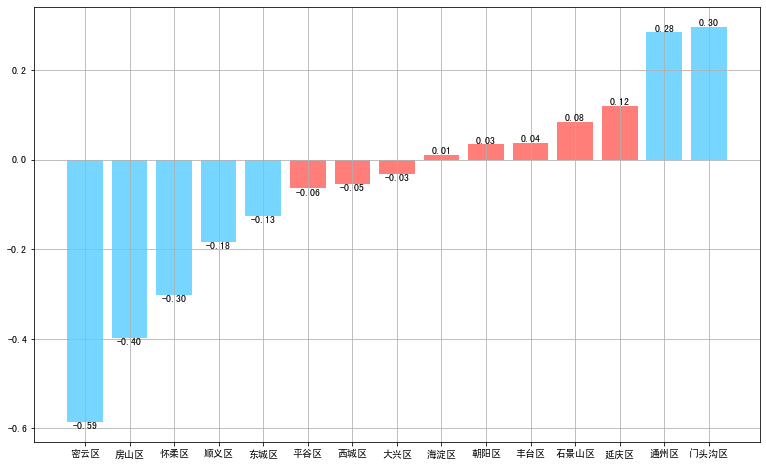

```python
### 画柱状图
color = np.where(p_value < 0.05,'#76D6FF','#FF7E79') ###显著的用蓝色，不显著的用红色
plt.figure(figsize = (13,8))
bar_chart = plt.bar(params.index,params,color = color)
plt.bar_label(bar_chart,fmt = '%.2f')
plt.grid()
```

### 可以看到两边系数绝对值较大的区p值较小，比较显著，而中间系数绝对值较小的区p值较大，显著性较低。

# 7. 假设你要开一家外卖店，并有如下打算，请预测其未来的（已经不是新店）月销量。

### 1）在长宁区经营快餐简餐（非品牌店），目标客户是学生党，平均每单费用约为20元（可参考北京与长宁区定位相似的行政区）；

### 2）使用蜂鸟专送，配送费6元，配送时间约为45分钟；

### 3）不可开发票；

### 4）综合评分(new_score)约为0.65分；

### 5）满减折扣率约为35%、其他活动数5个、没有新用户减免；

### 6）每天营业11小时，且在18点和23点都营业。

```python
### 第七题
X_predict = bic_X_train.iloc[-1].copy() ###快速构建一个和训练集样本字段相同的预测样本
X_predict[:] = 0 ###每个字段初始化
X_predict['const'] = 1
X_predict['东城区'] = 1 ### 长宁区和东城区比较像，所以设定为东城区
X_predict['快餐简餐'] = 1 ###该店卖快餐简餐
X_predict['log_average_cost'] = np.log(20 + 1) ###平均客单价为20
X_predict['order_lead_time'] = 45 ###平均配送时间为45分钟
X_predict['log_float_delivery_fee'] = np.log(6 + 1) ###配送费为6
X_predict['manjian_discount'] = 0.35 ###满减为35%
X_predict['other_activities'] = 5 ###其他优惠活动为5
X_predict['open_time'] = 11 ###营业时间为11小时
X_predict['open18'] = 1 ###18点营业
X_predict['open23'] = 1 ###23点营业
###非品牌店，非新店，蜂鸟专送，不可开票都默认为0，不需要重新设置。
X_predict ### 查看预测样本信息
```

```
const                      1.000000
manjian_discount           0.350000
order_lead_time           45.000000
is_new                     0.000000
is_premium                 0.000000
log_average_cost           3.044522
open_time                 11.000000
other_activities           5.000000
log_float_delivery_fee     1.945910
票                          0.000000
delivery_mode              0.000000
open18                     1.000000
保                          0.000000
open23                     1.000000
东城区                        1.000000
丰台区                        0.000000
大兴区                        0.000000
密云区                        0.000000
平谷区                        0.000000
延庆区                        0.000000
怀柔区                        0.000000
房山区                        0.000000
朝阳区                        0.000000
海淀区                        0.000000
石景山区                       0.000000
西城区                        0.000000
通州区                        0.000000
门头沟区                       0.000000
顺义区                        0.000000
小吃夜宵                       0.000000
异国料理                       0.000000
快餐简餐                       1.000000
特色菜系                       0.000000
甜品饮品                       0.000000
Name: 32042, dtype: float64
```

```python
log_val = float(bic_model.predict(X_predict)) ###计算预测的对数月销量
residual = 0
for i in range(len(bic_X_train)):
    residual += (bic_y_train[i] - float(bic_model.predict(bic_X_train.iloc[i]))) ** 2
sigma2 = residual/(len(bic_X_train - len(select) - 1)) ###计算sigma平方
val = np.exp(log_val + sigma2 / 2 ) - 1 ###对数月销量转化为月销量
print(F"对数月销量: {round(log_val,3)}, 月销量: {int(val)}")
```

```
对数月销量: 6.115, 月销量: 1094
```

### 可以看到预测值为6.115, 因此预测月销量为 1094 单